# Project 1 Team 8 - Patient Survival Prediction (EDA)

The ability to predict a patient’s chance of survival is essential since it not only aids medical professionals in making the best decisions but also raises the bar for medical treatment as a whole. So we decided to explore the exciting field of patient survival prediction. We chose the dataset from the Kaggle website. The data was collected during the COVID-19 pandemic. The dataset is in its raw form. Prior to moving on to feature importance, partitioning the data for training and testing, and model development, we have pre processed (EDA) the data to clean it. This comprises taking care of missing values, outliers, visualization etc. From analyzing the dataset, we will determine whether a patient lives or dies based on numerous parameters, like heart rate, creatinine, bilirubin levels, etc. Keeping patients’ medical history in mind, we can predict the survival rate by training an ML model with the data and testing it with different information. This research topic is a practical use case scenario as it will help doctors get to know the exact health condition of a patient without running many diagnoses. This data and the model built on this can save both time and the lives of people. From this data, we can also infer the significance/ impact of Intensive Care Units and check whether they really improve a patient’s health or not.

Understanding data:

```r
p<-read.csv("C:\\Users\\hp\\Documents\\GitHub\\FA-23_DATS_6101-Team_8\\Dataset1.csv")
print(str(p))
```

```
## 'data.frame':    91713 obs. of  17 variables:
##  $ patient_id       : int  25312 59342 50777 46918 34377 74489 49526 50129 10577 90749 ...
##  $ hospital_id      : int  118 81 118 118 33 83 83 33 118 118 ...
##  $ hospital_death   : int  0 0 0 0 0 0 0 0 1 0 ...
##  $ age              : int  68 77 25 81 19 67 59 70 45 50 ...
##  $ bmi              : num  22.7 27.4 31.9 22.6 NA ...
##  $ ethnicity        : chr  "Caucasian" "Caucasian" "Caucasian" "Caucasian" ...
##  $ gender           : chr  "M" "F" "F" "F" ...
##  $ icu_type         : chr  "CTICU" "Med-Surg ICU" "Med-Surg ICU" "CTICU" ...
##  $ bilirubin_apache : num  0.4 NA NA NA NA NA NA NA 0.2 0.4 ...
##  $ creatinine_apache: num  2.51 0.56 NA NA NA 0.71 0.78 2.05 1.16 0.83 ...
##  $ glucose_apache   : num  168 145 NA 185 NA 156 197 164 380 134 ...
##  $ heart_rate_apache: int  118 120 102 114 60 113 133 120 82 94 ...
##  $ diabetes_mellitus: int  1 1 0 0 0 1 1 0 0 0 ...
##  $ cirrhosis        : int  0 0 0 0 0 0 0 0 0 0 ...
##  $ hepatic_failure  : int  0 0 0 0 0 0 0 0 0 0 ...
##  $ leukemia         : int  0 0 0 0 0 0 0 0 0 0 ...
##  $ lymphoma         : int  0 0 0 0 0 0 0 0 0 0 ...
## NULL
```

```r
summary((p))
```

```
##    patient_id      hospital_id  hospital_death       age            bmi
##  Min.   :     1   Min.   :  2   Min.   :0.000   Min.   :16     Min.   :15
##  1st Qu.: 32830   1st Qu.: 47   1st Qu.:0.000   1st Qu.:52     1st Qu.:24
##  Median : 65413   Median :109   Median :0.000   Median :65     Median :28
##  Mean   : 65537   Mean   :106   Mean   :0.086   Mean   :62     Mean   :29
##  3rd Qu.: 98298   3rd Qu.:161   3rd Qu.:0.000   3rd Qu.:75     3rd Qu.:33
##  Max.   :131051   Max.   :204   Max.   :1.000   Max.   :89     Max.   :68
##                                                 NA's   :4228   NA's   :3429
##   ethnicity            gender            icu_type         bilirubin_apache
##  Length:91713       Length:91713       Length:91713       Min.   : 0
##  Class :character   Class :character   Class :character   1st Qu.: 0
##  Mode  :character   Mode  :character   Mode  :character   Median : 1
##                                                           Mean   : 1
##                                                           3rd Qu.: 1
##                                                           Max.   :51
##                                                           NA's   :58134
##  creatinine_apache glucose_apache  heart_rate_apache diabetes_mellitus
##  Min.   : 0        Min.   : 39     Min.   : 30       Min.   :0
##  1st Qu.: 1        1st Qu.: 97     1st Qu.: 86       1st Qu.:0
##  Median : 1        Median :133     Median :104       Median :0
##  Mean   : 1        Mean   :160     Mean   :100       Mean   :0
##  3rd Qu.: 2        3rd Qu.:196     3rd Qu.:120       3rd Qu.:0
##  Max.   :11        Max.   :599     Max.   :178       Max.   :1
##  NA's   :18853     NA's   :11036   NA's   :878       NA's   :715
##    cirrhosis   hepatic_failure    leukemia      lymphoma
##  Min.   :0     Min.   :0       Min.   :0     Min.   :0
##  1st Qu.:0     1st Qu.:0       1st Qu.:0     1st Qu.:0
##  Median :0     Median :0       Median :0     Median :0
##  Mean   :0     Mean   :0       Mean   :0     Mean   :0
##  3rd Qu.:0     3rd Qu.:0       3rd Qu.:0     3rd Qu.:0
##  Max.   :1     Max.   :1       Max.   :1     Max.   :1
##  NA's   :715   NA's   :715     NA's   :715   NA's   :715
```

```r
p$ethnicity<-as.factor(p$ethnicity)
p$gender<-as.factor(p$gender)
p$gender<-as.factor(p$icu_type)
#summary(p)

p <- p[, !names(p) %in% c('bilirubin_apache')]
p <- p[, !names(p) %in% c('creatinine_apache')]
p <- p[, !names(p) %in% c('glucose_apache')]
str(p)
```

```
## 'data.frame':    91713 obs. of  14 variables:
##  $ patient_id       : int  25312 59342 50777 46918 34377 74489 49526 50129 10577 90749 ...
##  $ hospital_id      : int  118 81 118 118 33 83 83 33 118 118 ...
##  $ hospital_death   : int  0 0 0 0 0 0 0 0 1 0 ...
##  $ age              : int  68 77 25 81 19 67 59 70 45 50 ...
##  $ bmi              : num  22.7 27.4 31.9 22.6 NA ...
##  $ ethnicity        : Factor w/ 7 levels "","African American",..: 4 4 4 4 4 4 4 4 4 1 ...
##  $ gender           : Factor w/ 8 levels "Cardiac ICU",..: 4 5 5 4 5 5 5 5 2 2 ...
##  $ icu_type         : chr  "CTICU" "Med-Surg ICU" "Med-Surg ICU" "CTICU" ...
##  $ heart_rate_apache: int  118 120 102 114 60 113 133 120 82 94 ...
##  $ diabetes_mellitus: int  1 1 0 0 0 1 1 0 0 0 ...
##  $ cirrhosis        : int  0 0 0 0 0 0 0 0 0 0 ...
##  $ hepatic_failure  : int  0 0 0 0 0 0 0 0 0 0 ...
##  $ leukemia         : int  0 0 0 0 0 0 0 0 0 0 ...
##  $ lymphoma         : int  0 0 0 0 0 0 0 0 0 0 ...
```

Cleaning the data:

One of the most important steps in the exploratory data analysis is data cleaning. It is vital to understand the data and check if there are any missing values or outliers in the data. The presence of these may affect the distribution and lead to inaccurate results during the model building process. The presence of outliers pull the collective mean towards themselves because of their extreme values which may lead to inefficient understanding of the data. In most cases missing values in data may lead to biased results. Hence, handling these outliers and missing values is the first and most significant step in eda.

Identifying NA’s

We can identify the missing values in our data using the summary function in R. It gives the count of NA’s in every column. If we replace the blank spaces as NA’s we can find the total number of these occurrences. There are a lot of ways to handle this. We can either impute the missing values with mean or mode if the column has levels (ex. Factor variable with ratings 1,2,3,4 etc.,) or we could remove the columns which contain the most NA’s only if it is approved by the domain expert that this column won’t have much impact on the data even if we remove it . Another way is to remove the rows which contain the missing values only if the number of rows removed is a amounts to negligible percent of the whole data as we can’t remove half of the data because it contains NA’s because it will be futile to build a model with the less number of inputs without considering all cases.

Handling NA’s

In our project, we have removed some columns such as “bilirubin apache”, “creatinine apache” etc which do not concern our SMART questions and which have the most number of NA’s. After this we have removed the rows which contained the rest of the NA’s. The final data after this process came down to roughly 82,000 rows out of 90,000 with 14 columns. Since we thought the amount of NA’s removed were only a small insignificant portion of data, we went ahead with the removal process.

```r
p[p == ''] <- NA
s=na.omit(p)
#summary(p)
s[1:10,]
```

```
##    patient_id hospital_id hospital_death age  bmi ethnicity       gender
## 1       25312         118              0  68 22.7 Caucasian        CTICU
## 2       59342          81              0  77 27.4 Caucasian Med-Surg ICU
## 3       50777         118              0  25 31.9 Caucasian Med-Surg ICU
## 4       46918         118              0  81 22.6 Caucasian        CTICU
## 6       74489          83              0  67 27.6 Caucasian Med-Surg ICU
## 7       49526          83              0  59 57.5 Caucasian Med-Surg ICU
## 11     125898          77              0  72 28.3  Hispanic Med-Surg ICU
## 12      78266          83              0  80 27.4 Caucasian Med-Surg ICU
## 15      98174         118              0  81 38.2 Caucasian         MICU
## 17      71252          81              0  30 23.4 Caucasian Med-Surg ICU
##        icu_type heart_rate_apache diabetes_mellitus cirrhosis hepatic_failure
## 1         CTICU               118                 1         0               0
## 2  Med-Surg ICU               120                 1         0               0
## 3  Med-Surg ICU               102                 0         0               0
```

[output cut: 18 more lines]

```r
#summary(s)
nrow(s)
```

```
## [1] 82954
```

Plots before outlier removal

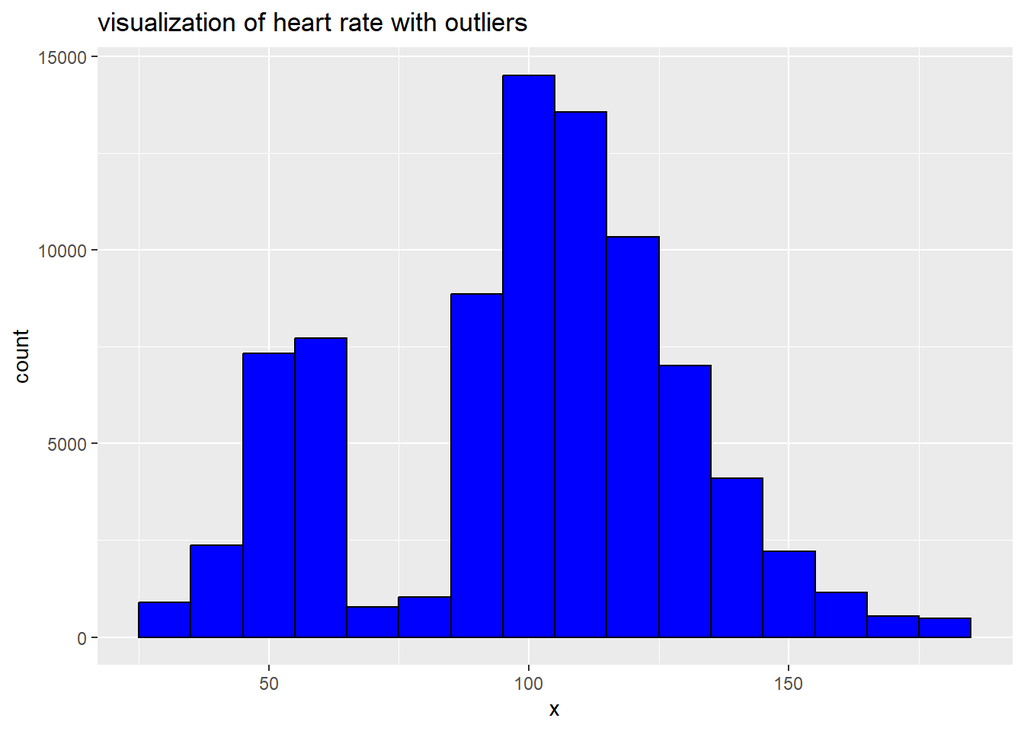

```r
library(ggplot2)
ggplot(data.frame(x=s$heart_rate_apache), aes(x))+geom_histogram(binwidth = 10, color="black",fill="blue")+labs(xlab="heart rate apache", ylab="frequency",title="visualization of heart rate with outliers")
```

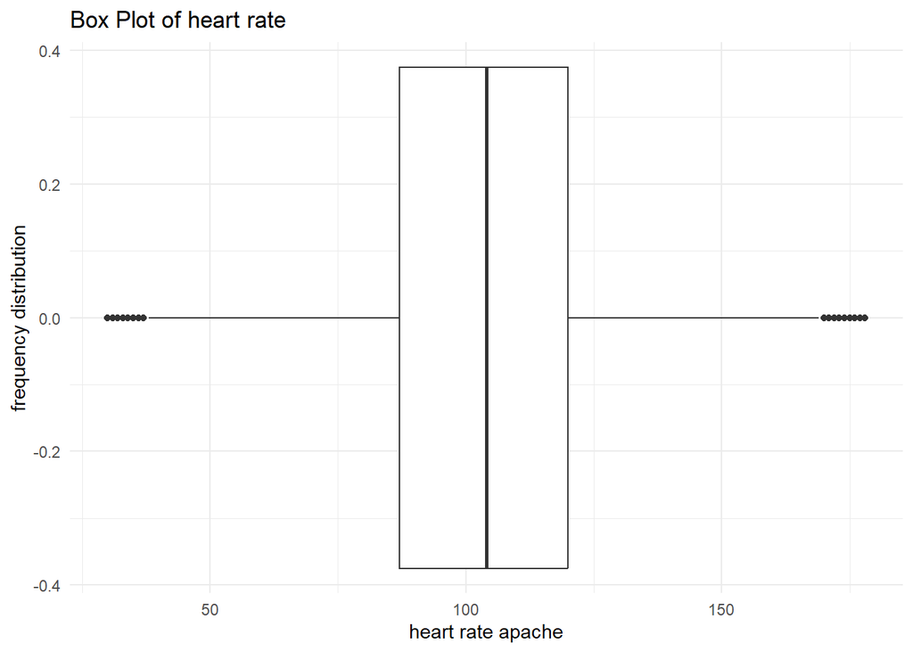

```r
ggplot(s, aes(x = heart_rate_apache), y = "") +
  geom_boxplot() +
  labs(title = "Box Plot of heart rate",
       x = "heart rate apache", y = "frequency distribution") +
  theme_minimal()
```

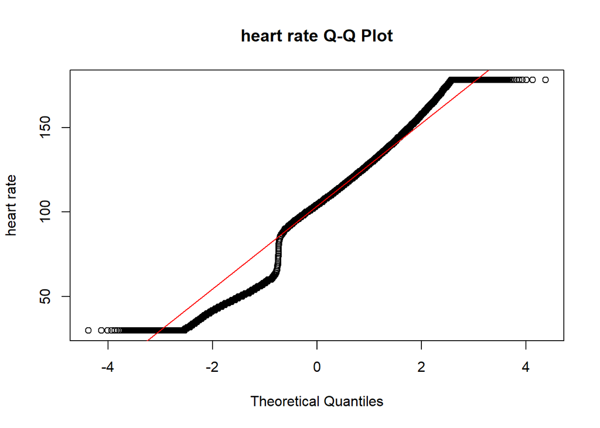

```r
qqnorm(s$heart_rate_apache, main = "heart rate Q-Q Plot", ylab="heart rate", datax=FALSE)
qqline(s$heart_rate_apache, col = "red")
```

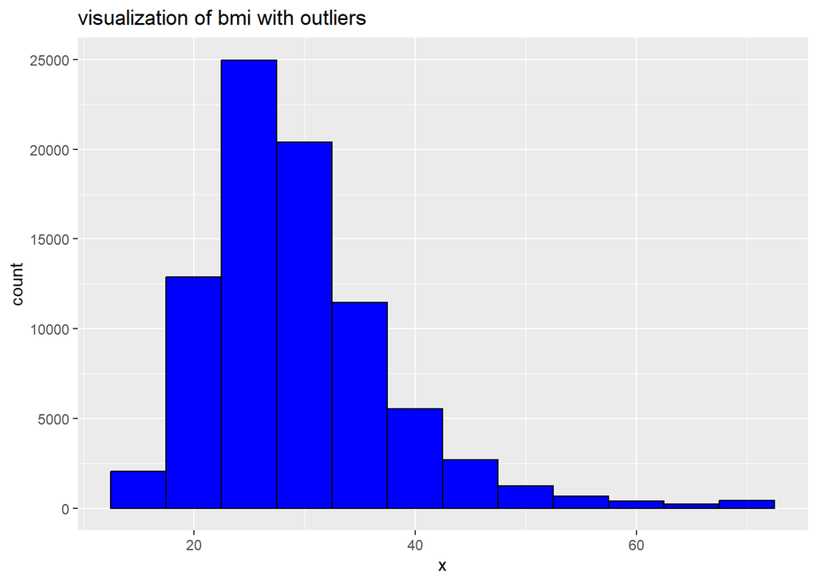

```r
library(ggplot2)
ggplot(data.frame(x=s$bmi), aes(x))+geom_histogram(binwidth = 5, color="black",fill="blue")+labs(xlab="bmi", ylab="frequency",title="visualization of bmi with outliers")
```

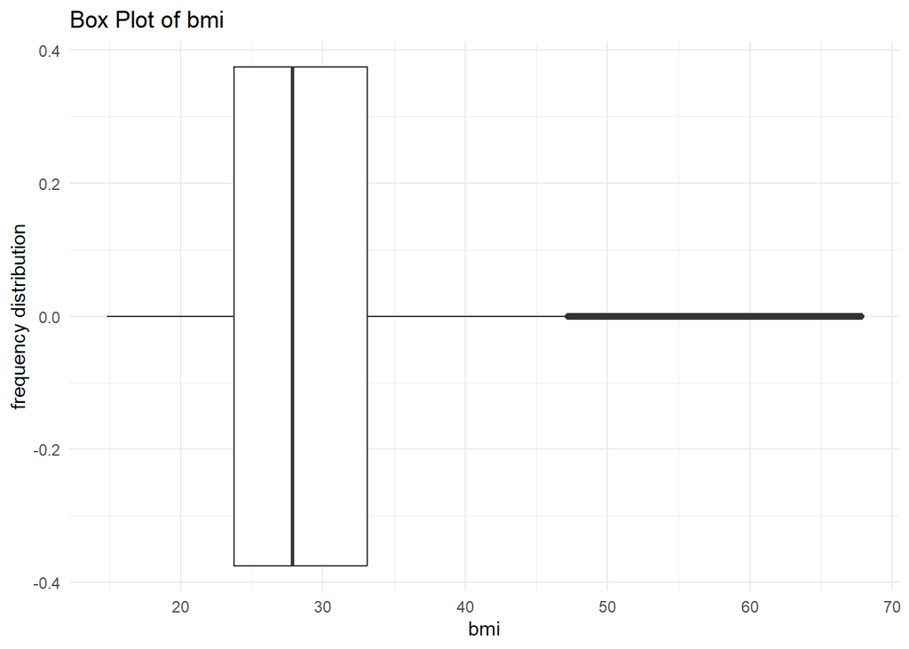

```r
ggplot(s, aes(x = bmi), y = "") +
  geom_boxplot() +
  labs(title = "Box Plot of bmi",
       x = "bmi", y = "frequency distribution") +
  theme_minimal()
```

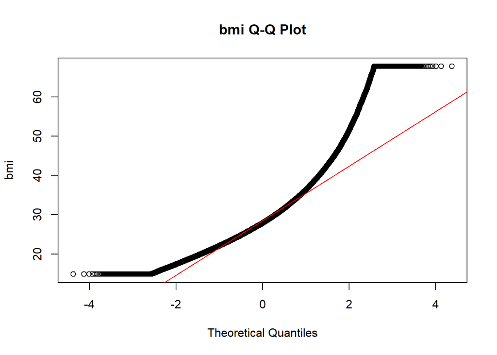

```r
qqnorm(s$bmi, main = "bmi Q-Q Plot", ylab="bmi", datax=FALSE)
qqline(s$bmi, col = "red")
```

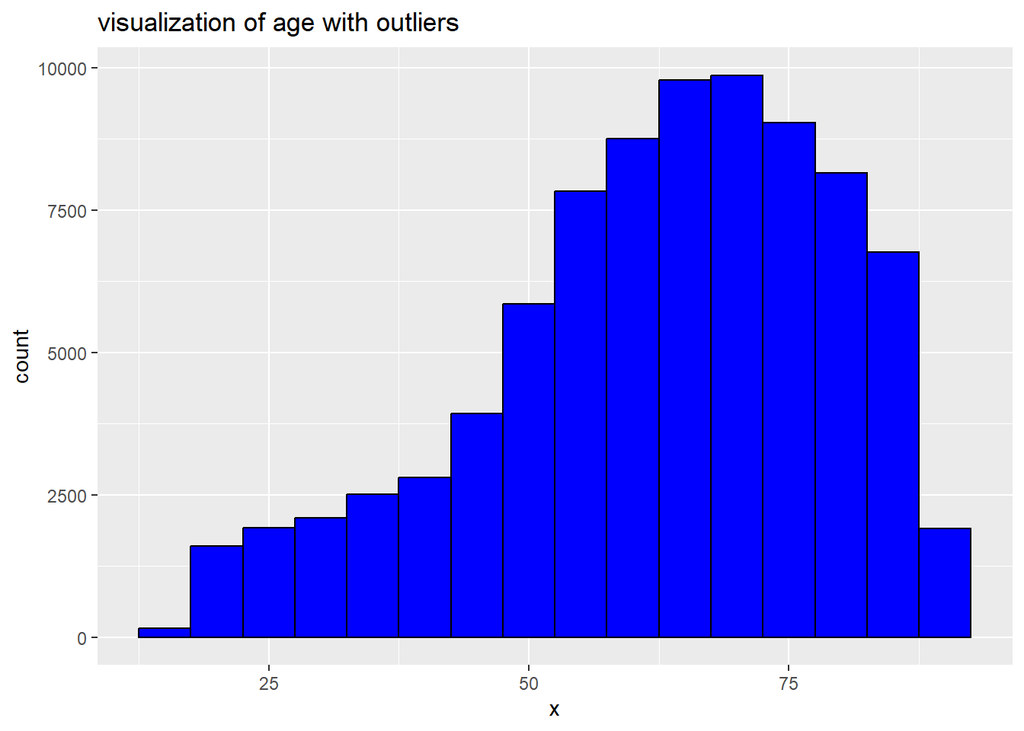

```r
library(ggplot2)
ggplot(data.frame(x=s$age), aes(x))+geom_histogram(binwidth = 5, color="black",fill="blue")+labs(xlab="age", ylab="frequency",title="visualization of age with outliers")
```

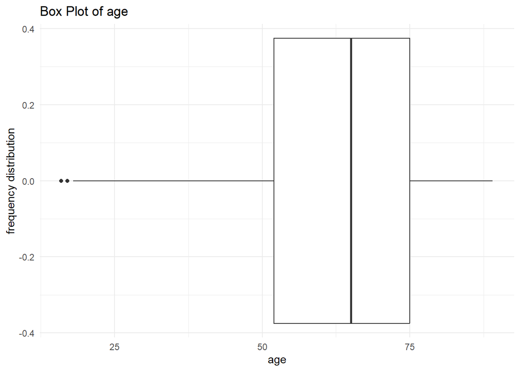

```r
ggplot(s, aes(x = age), y = "") +
  geom_boxplot() +
  labs(title = "Box Plot of age",
       x = "age", y = "frequency distribution") +
  theme_minimal()
```

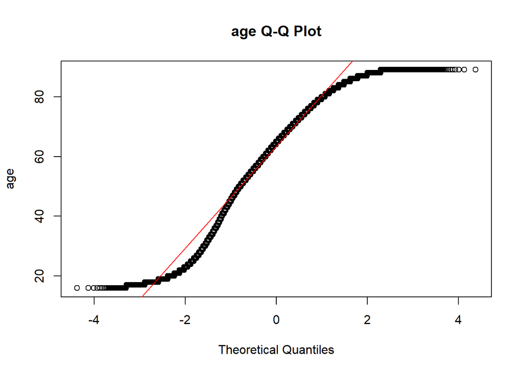

```r
qqnorm(s$age, main = "age Q-Q Plot", ylab="age", datax=FALSE)
qqline(s$age, col = "red")
```

Identifying outliers

To identify the outliers in this data, we can use visualization techniques such as plots namely, histograms, box plots, Q-Q plots etc. The box and qq plots are accurate than most in showing the outliers and their impact on the data. These plots are capable in showing the skewness of the distribution as well. The box plots show the inter quartile ranges as well along with the median of data apart from indicating the outlier presence.

In our project, we have used histograms, qq plots and box plots in visualizing the outliers. We’ve plotted charts of data with and without outliers to understand and assess the impact of outliers. Since, it is suitable to plot charts for only continuous variables we have used the above mentioned visualization techniques on columns like “bmi”, “heart rate apache”, and “age”. From the histogram of heart rate column we could infer that, the distribution was bi modal since it has two peaks. We can observe that the heart rate is increasing at first and then decrasing in the interval of 0-60 and following the same pattern from 100-150. The box and qq plots indicated that outliers are present by showing the circle dots/indications at the ends. These plots demonstrate the count, frequency distribution and theoretical quantiles pertaining to the data. From the histogram of “bmi” column with outliers, it is evident that the graph is right skewed (as most of the data is to the left leaving the tail to the right). From this, we can observe that most of the people have bmi ranging from 0-40. The box as well as the median line are to the left in the box plot indicating skewness towards right. The data points at the end of the qq plot are towards the upper position from the qq line indicating right skewness with outliers at both ends. Whereas, if we observe the histogram of age variable, we can infer that the data is left skewed (as most of the data is to the right leaving the tail to the left). This means, most of the data in the dataset concerns people with age fifty and higher. The box plot is also towards the right with outliers towards the left indicating left skewed data distribution. Even the qq plot is indicating the same distribution with data points falling below the qq line with outliers at both ends.

Handling Outliers

```r
c <- s$heart_rate_apache

q1 <- quantile(c, 0.25)
q3 <- quantile(c, 0.75)

iqr_value <- IQR(c)

lower_bound <- q1 - 1.5 * iqr_value
upper_bound <- q3 + 1.5 * iqr_value


outliers <- s[c < lower_bound | c > upper_bound, ]


#print("Outliers:")
#print(outliers)

print("Lower Bound heart rate:")
```

```
## [1] "Lower Bound heart rate:"
```

```r
print(lower_bound)
```

```
##  25%
## 37.5
```

```r
print("Upper Bound heart rate:")
```

```
## [1] "Upper Bound heart rate:"
```

```r
print(upper_bound)
```

```
## 75%
## 170
```

```r
cleaned_data <- s[!(s$heart_rate_apache %in% outliers$heart_rate_apache),]
nrow(cleaned_data)
```

```
## [1] 81052
```

```r
#library(ggplot2)
#ggplot(data.frame(x=cleaned_data$heart_rate_apache), aes(x))+geom_histogram(binwidth = 2, #color="black",fill="blue")+labs(title="visualization of heart rate without outliers")

#ggplot(data.frame(x=cleaned_data$bmi), aes(x))+geom_histogram(binwidth = 2, color="black",fill="blue")+labs(title="visualization of #bmi with outliers")
```

```r
c3 <- cleaned_data$bmi


q1bmi <- quantile(c3, 0.25)
q3bmi <- quantile(c3, 0.75)


iqr_valuebmi <- IQR(c3)


lower_boundbmi <- q1bmi - 1.5 * iqr_valuebmi
upper_boundbmi <- q3bmi + 1.5 * iqr_valuebmi


outliersbmi <- cleaned_data[c3 < lower_boundbmi | c3 > upper_boundbmi, ]


#print("Outliers:")
#print(outliersbmi)


print("Lower Bound bmi:")
```

```
## [1] "Lower Bound bmi:"
```

```r
print(lower_boundbmi)
```

```
##  25%
## 9.73
```

```r
print("Upper Bound bmi:")
```

```
## [1] "Upper Bound bmi:"
```

```r
print(upper_boundbmi)
```

```
##  75%
## 47.2
```

```r
cleaned_data3 <-cleaned_data[!(cleaned_data$bmi %in% outliersbmi$bmi),]
#nrow(s)
nrow(cleaned_data3)
```

```
## [1] 78069
```

```r
c4 <- cleaned_data3$age


q1age <- quantile(c4, 0.25)
q3age <- quantile(c4, 0.75)


iqr_valueage <- IQR(c4)


lower_boundage <- q1age - 1.5 * iqr_valueage
upper_boundage <- q3age + 1.5 * iqr_valueage


outliersage <- cleaned_data3[c4 < lower_boundage | c4 > upper_boundage, ]


#print("Outliers:")
#print(outliersage)


print("Lower Bound age:")
```

```
## [1] "Lower Bound age:"
```

```r
print(lower_boundage)
```

```
## 25%
##  20
```

```r
print("Upper Bound age:")
```

```
## [1] "Upper Bound age:"
```

```r
print(upper_boundage)
```

```
## 75%
## 108
```

```r
cleaned_data4 <-cleaned_data3[!(cleaned_data3$age %in% outliersage$age),]
#nrow(s)
nrow(cleaned_data4)
```

```
## [1] 77379
```

Plots for assessing relationships between variables

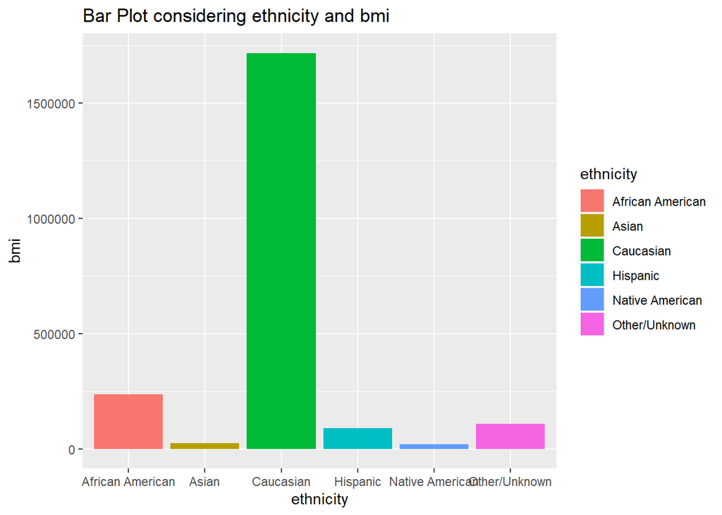

```r
ggplot(cleaned_data4, aes(x = ethnicity, y = bmi, fill = ethnicity)) +
 geom_col() +
  labs(title = "Bar Plot considering ethnicity and bmi",
       x = "ethnicity", y = "bmi")
```

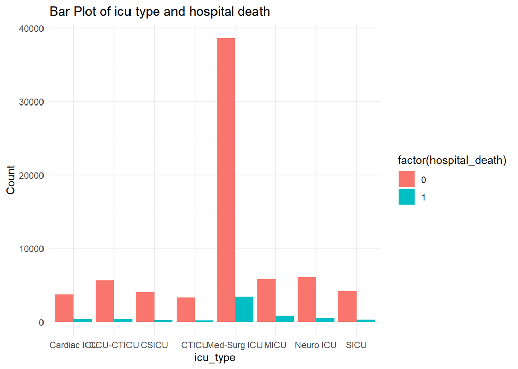

```r
ggplot(cleaned_data4, aes(x = icu_type, fill = factor(hospital_death))) +
  geom_bar(position = "dodge") +
  labs(title = "Bar Plot of icu type and hospital death",
       x = "icu_type", y = "Count") +
  theme_minimal()
```

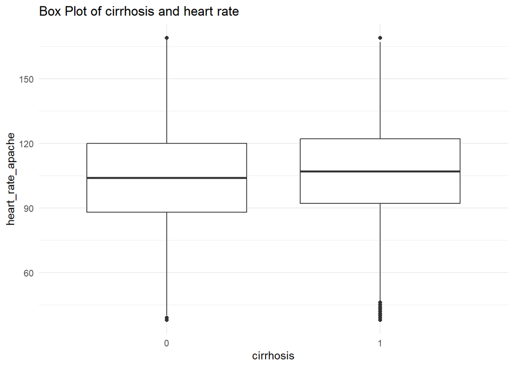

```r
# Box Plot
ggplot(cleaned_data4, aes(x = factor(cirrhosis), y = heart_rate_apache)) +
  geom_boxplot() +
  labs(title = "Box Plot of cirrhosis and heart rate",
       x = "cirrhosis", y = "heart_rate_apache") +
  theme_minimal()
```

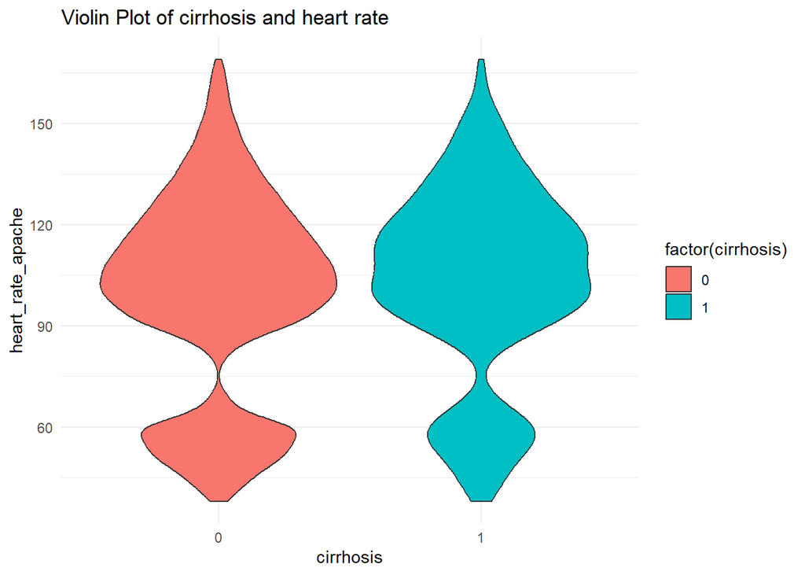

```r
# Violin Plot
ggplot(cleaned_data4, aes(x = factor(cirrhosis), y = heart_rate_apache, fill = factor(cirrhosis))) +
  geom_violin() +
  labs(title = "Violin Plot of cirrhosis and heart rate",
       x = "cirrhosis", y = "heart_rate_apache") +
  theme_minimal()
```

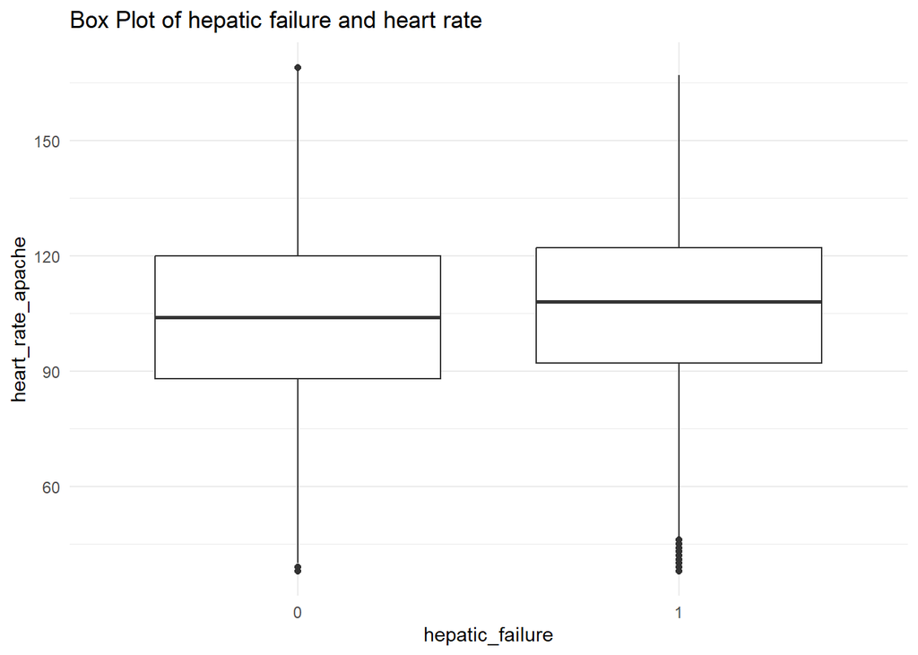

```r
# Box Plot
ggplot(cleaned_data4, aes(x = factor(hepatic_failure), y = heart_rate_apache)) +
  geom_boxplot() +
  labs(title = "Box Plot of hepatic failure and heart rate",
       x = "hepatic_failure", y = "heart_rate_apache") +
  theme_minimal()
```

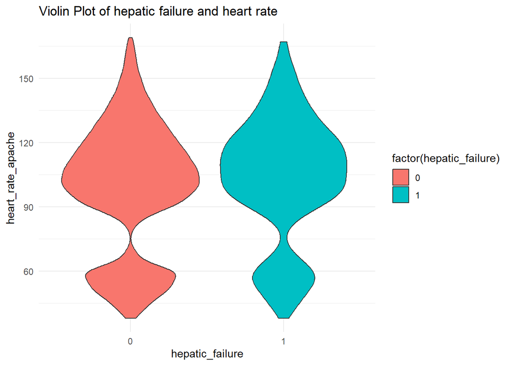

```r
# Violin Plot
ggplot(cleaned_data4, aes(x = factor(hepatic_failure), y = heart_rate_apache, fill = factor(hepatic_failure))) +
  geom_violin() +
  labs(title = "Violin Plot of hepatic failure and heart rate",
       x = "hepatic_failure", y = "heart_rate_apache") +
  theme_minimal()
```

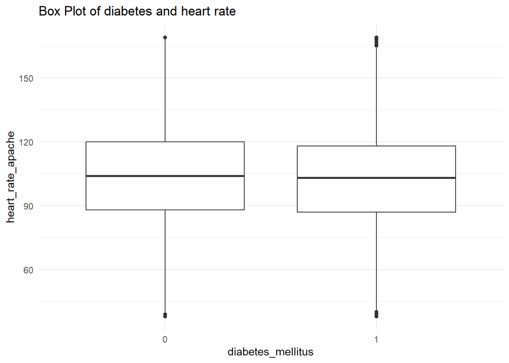

```r
# Box Plot
ggplot(cleaned_data4, aes(x = factor(diabetes_mellitus), y = heart_rate_apache)) +
  geom_boxplot() +
  labs(title = "Box Plot of diabetes and heart rate",
       x = "diabetes_mellitus", y = "heart_rate_apache") +
  theme_minimal()
```

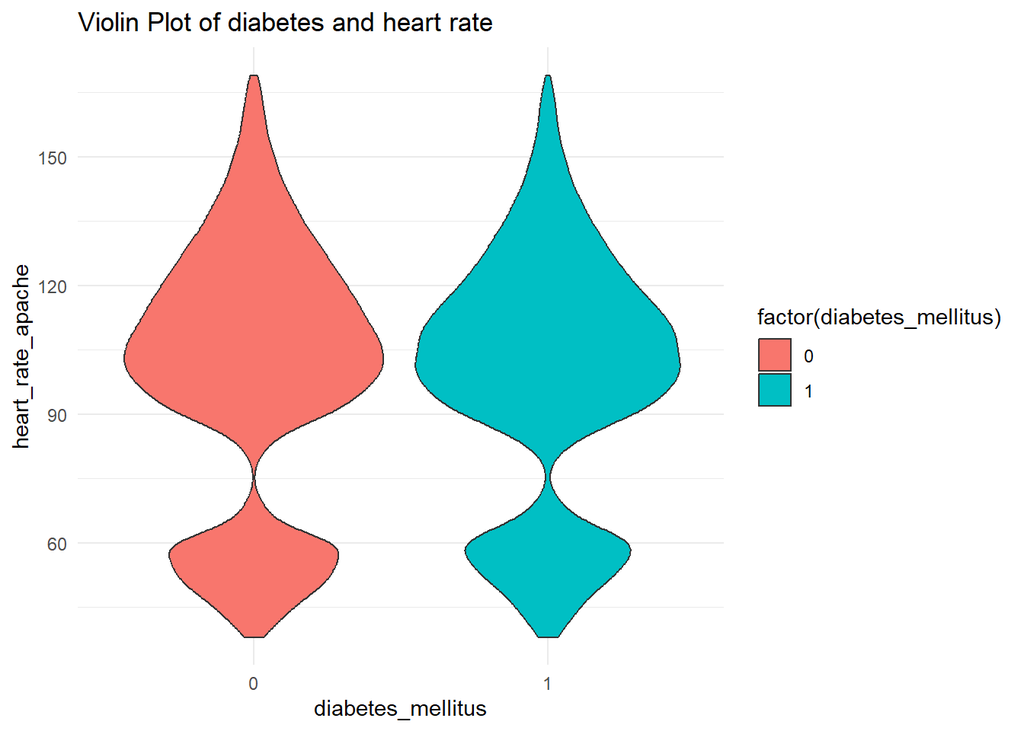

```r
# Violin Plot
ggplot(cleaned_data4, aes(x = factor(diabetes_mellitus), y = heart_rate_apache, fill = factor(diabetes_mellitus))) +
  geom_violin() +
  labs(title = "Violin Plot of diabetes and heart rate",
       x = "diabetes_mellitus", y = "heart_rate_apache") +
  theme_minimal()
```

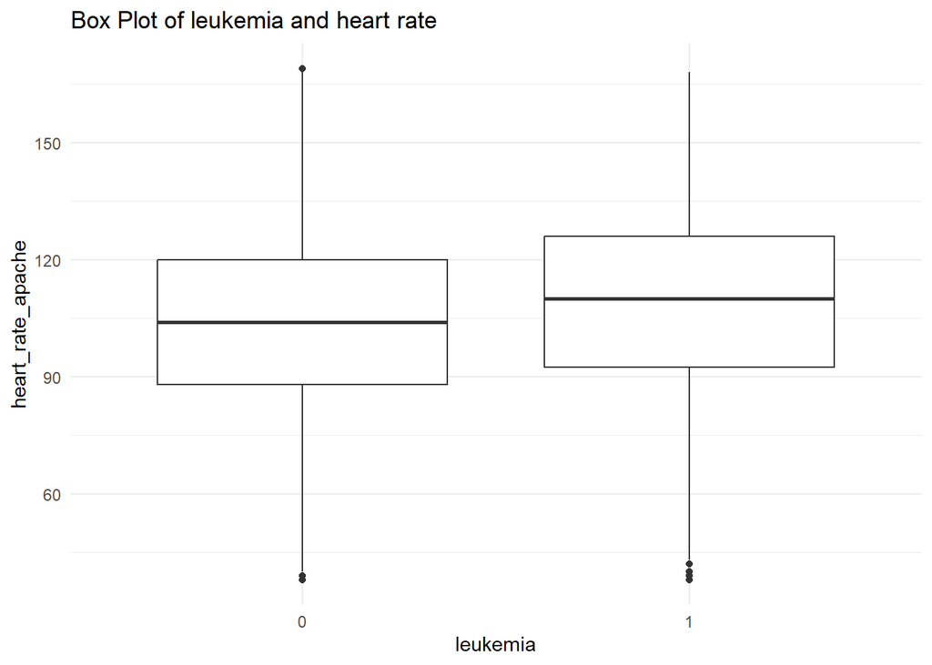

```r
# Box Plot
ggplot(cleaned_data4, aes(x = factor(leukemia), y = heart_rate_apache)) +
  geom_boxplot() +
  labs(title = "Box Plot of leukemia and heart rate",
       x = "leukemia", y = "heart_rate_apache") +
  theme_minimal()
```

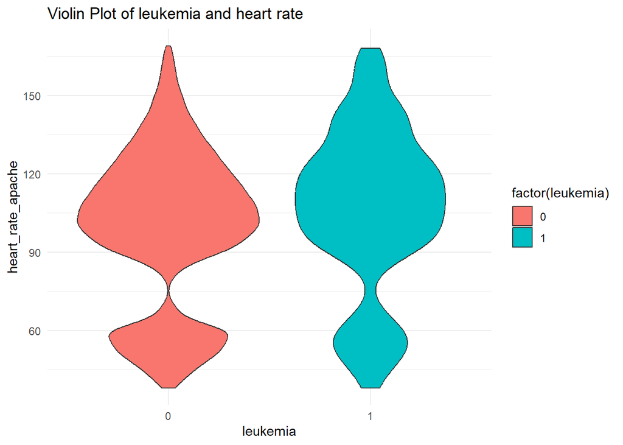

```r
# Violin Plot
ggplot(cleaned_data4, aes(x = factor(leukemia), y = heart_rate_apache, fill = factor(leukemia))) +
  geom_violin() +
  labs(title = "Violin Plot of leukemia and heart rate",
       x = "leukemia", y = "heart_rate_apache") +
  theme_minimal()
```

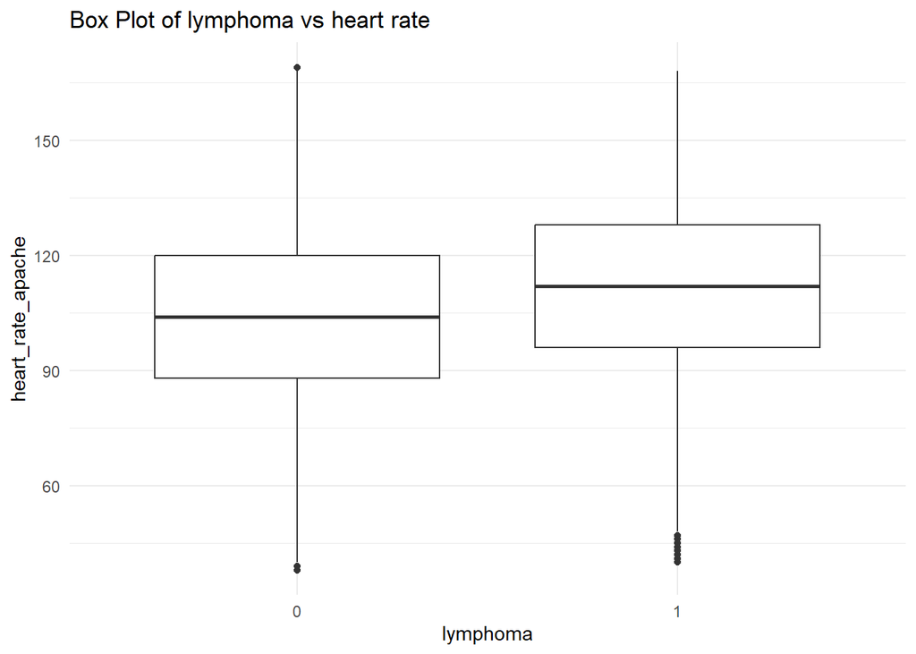

```r
# Box Plot
ggplot(cleaned_data4, aes(x = factor(lymphoma), y = heart_rate_apache)) +
  geom_boxplot() +
  labs(title = "Box Plot of lymphoma vs heart rate",
       x = "lymphoma", y = "heart_rate_apache") +
  theme_minimal()
```

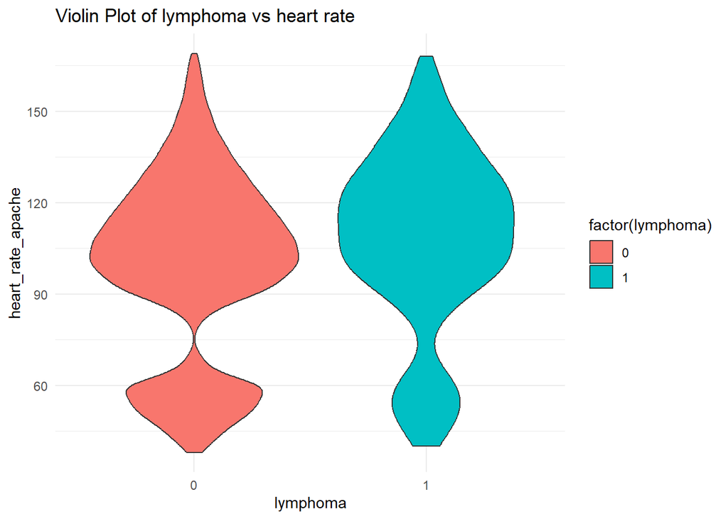

```r
# Violin Plot
ggplot(cleaned_data4, aes(x = factor(lymphoma), y = heart_rate_apache, fill = factor(lymphoma))) +
  geom_violin() +
  labs(title = "Violin Plot of lymphoma vs heart rate",
       x = "lymphoma", y = "heart_rate_apache") +
  theme_minimal()
```

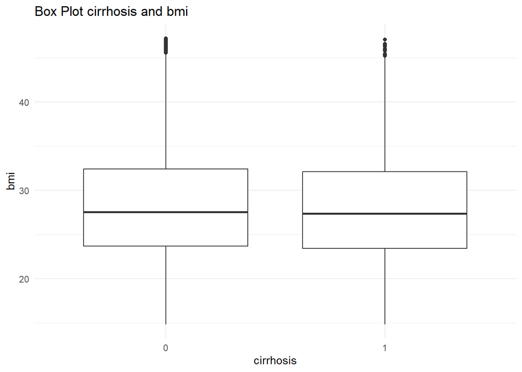

```r
# Box Plot
ggplot(cleaned_data4, aes(x = factor(cirrhosis), y = bmi)) +
  geom_boxplot() +
  labs(title = "Box Plot cirrhosis and bmi" ,
       x = "cirrhosis", y = "bmi") +
  theme_minimal()
```

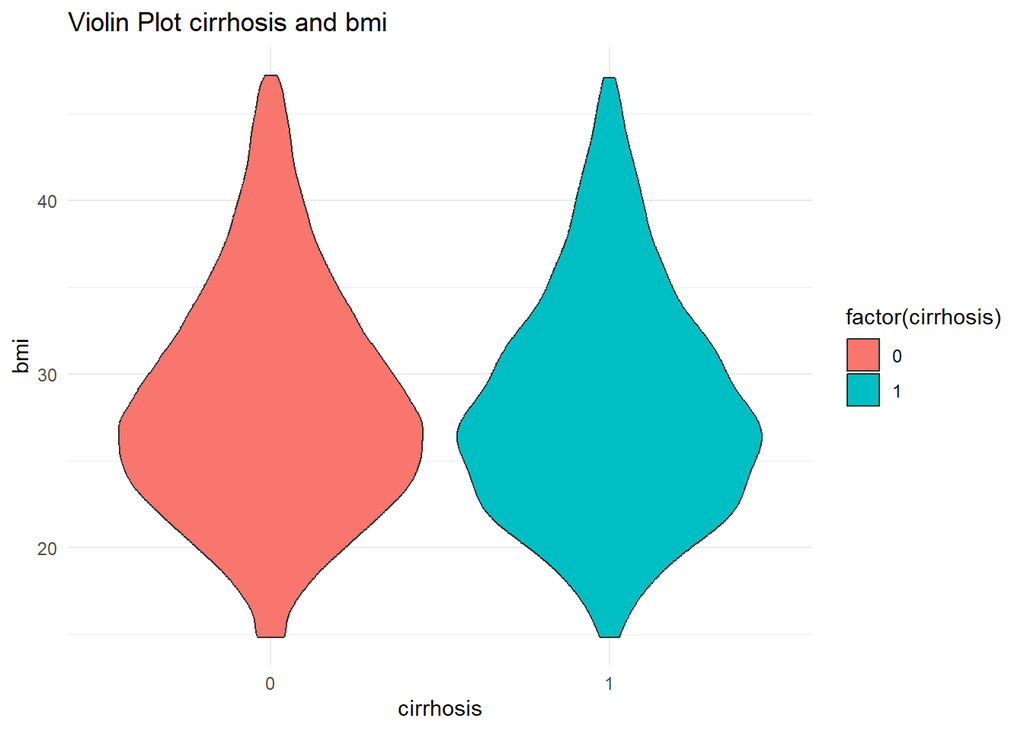

```r
# Violin Plot
ggplot(cleaned_data4, aes(x = factor(cirrhosis), y = bmi, fill = factor(cirrhosis))) +
  geom_violin() +
  labs(title = "Violin Plot cirrhosis and bmi",
       x = "cirrhosis", y = "bmi") +
  theme_minimal()
```

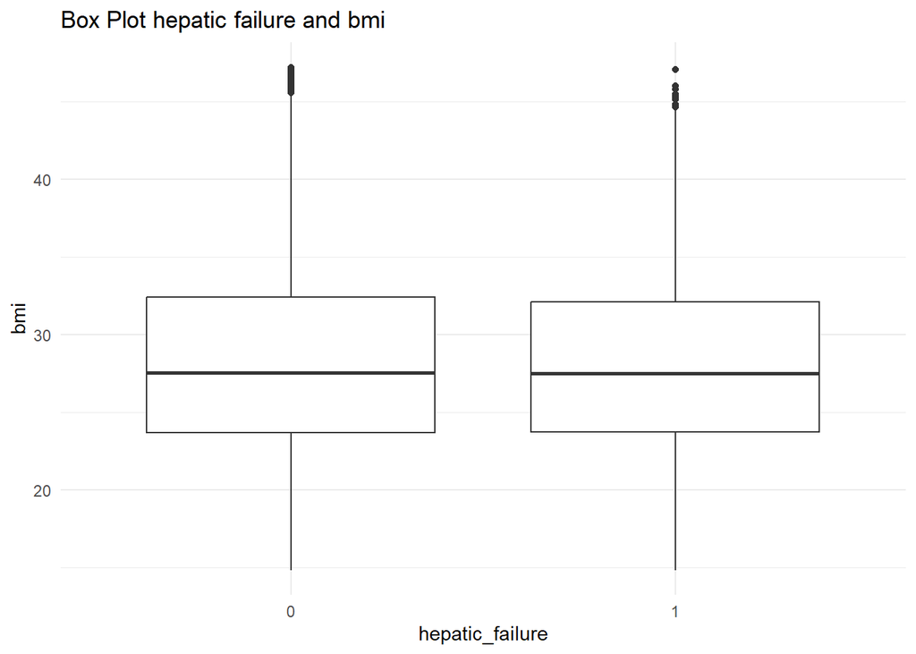

```r
# Box Plot
ggplot(cleaned_data4, aes(x = factor(hepatic_failure), y = bmi)) +
  geom_boxplot() +
  labs(title = "Box Plot hepatic failure and bmi",
       x = "hepatic_failure", y = "bmi") +
  theme_minimal()
```

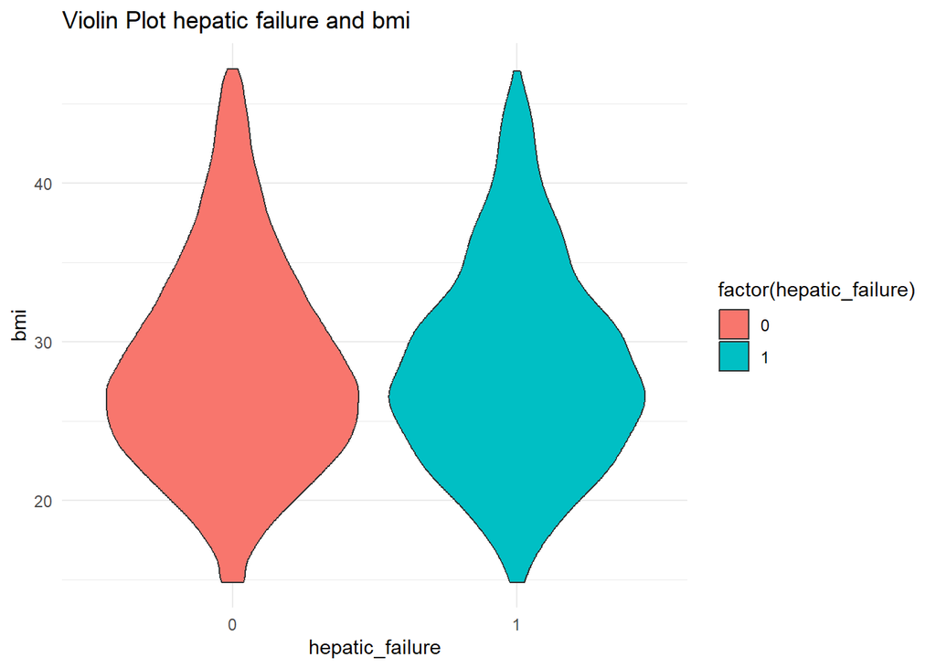

```r
# Violin Plot
ggplot(cleaned_data4, aes(x = factor(hepatic_failure), y = bmi, fill = factor(hepatic_failure))) +
  geom_violin() +
  labs(title = "Violin Plot hepatic failure and bmi",
       x = "hepatic_failure", y = "bmi") +
  theme_minimal()
```

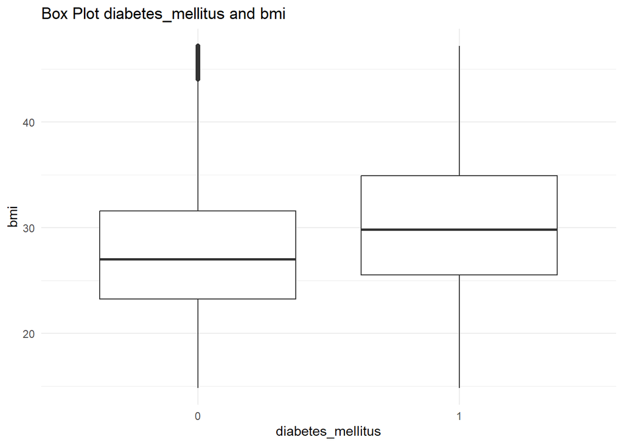

```r
# Box Plot
ggplot(cleaned_data4, aes(x = factor(diabetes_mellitus), y = bmi)) +
  geom_boxplot() +
  labs(title = "Box Plot diabetes_mellitus and bmi",
       x = "diabetes_mellitus", y = "bmi") +
  theme_minimal()
```

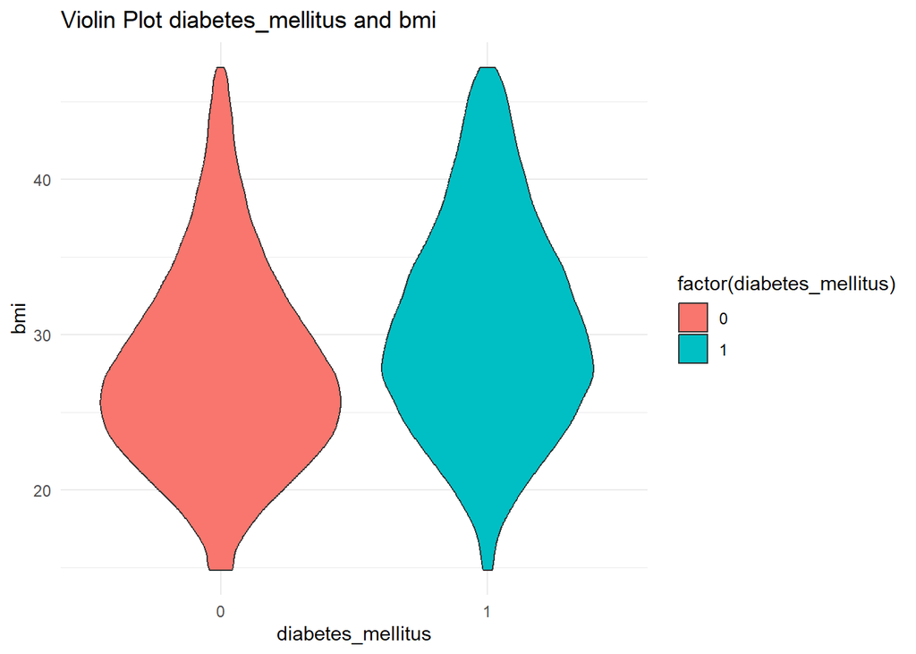

```r
# Violin Plot
ggplot(cleaned_data4, aes(x = factor(diabetes_mellitus), y = bmi, fill = factor(diabetes_mellitus))) +
  geom_violin() +
  labs(title = "Violin Plot diabetes_mellitus and bmi",
       x = "diabetes_mellitus", y = "bmi") +
  theme_minimal()
```

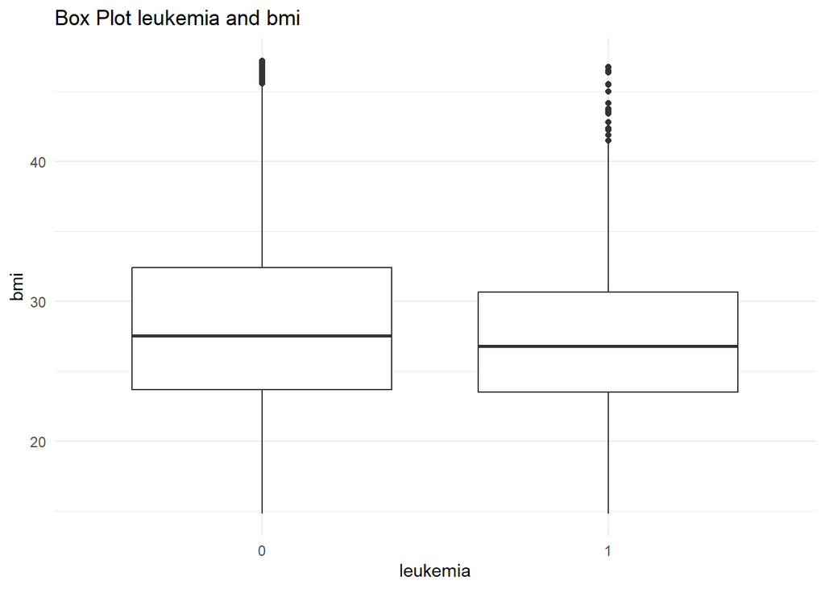

```r
# Box Plot
ggplot(cleaned_data4, aes(x = factor(leukemia), y = bmi)) +
  geom_boxplot() +
  labs(title = "Box Plot leukemia and bmi",
       x = "leukemia", y = "bmi") +
  theme_minimal()
```

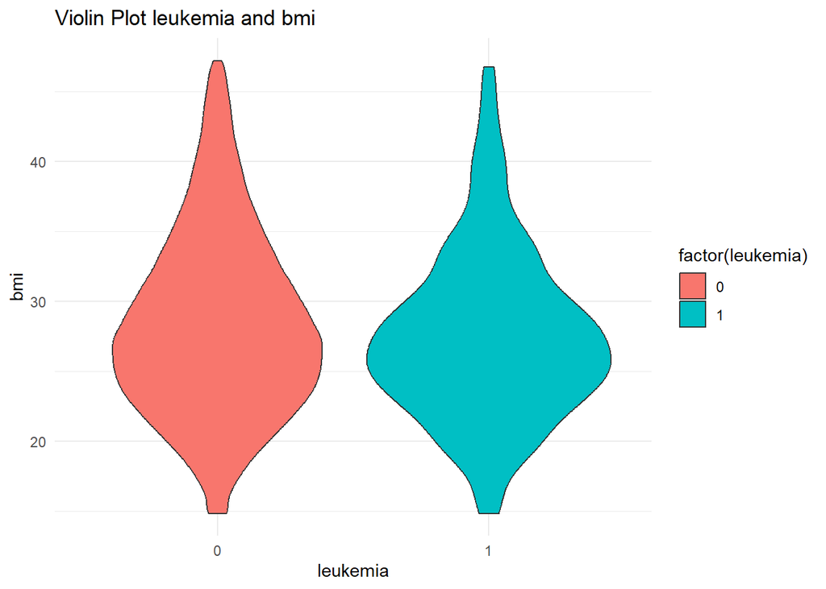

```r
# Violin Plot
ggplot(cleaned_data4, aes(x = factor(leukemia), y = bmi, fill = factor(leukemia))) +
  geom_violin() +
  labs(title = "Violin Plot leukemia and bmi",
       x = "leukemia", y = "bmi") +
  theme_minimal()
```

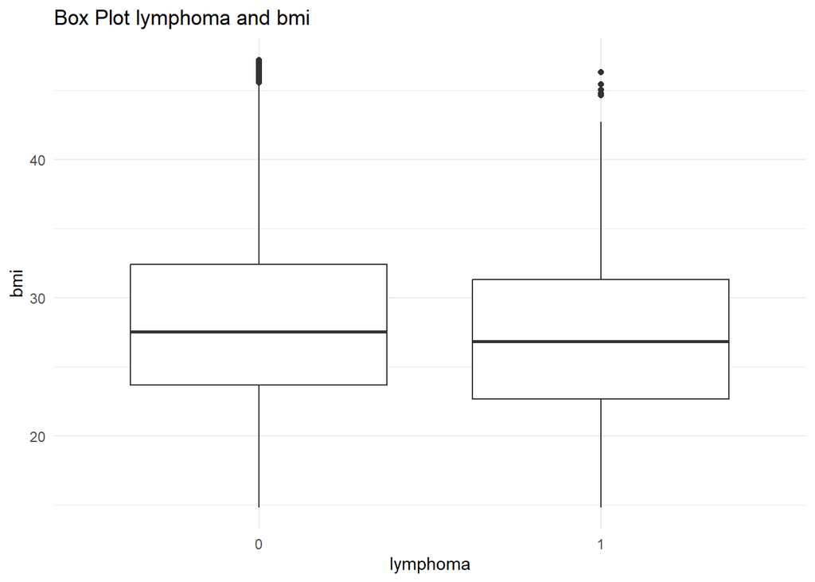

```r
# Box Plot
ggplot(cleaned_data4, aes(x = factor(lymphoma), y = bmi)) +
  geom_boxplot() +
  labs(title = "Box Plot lymphoma and bmi",
       x = "lymphoma", y = "bmi") +
  theme_minimal()
```

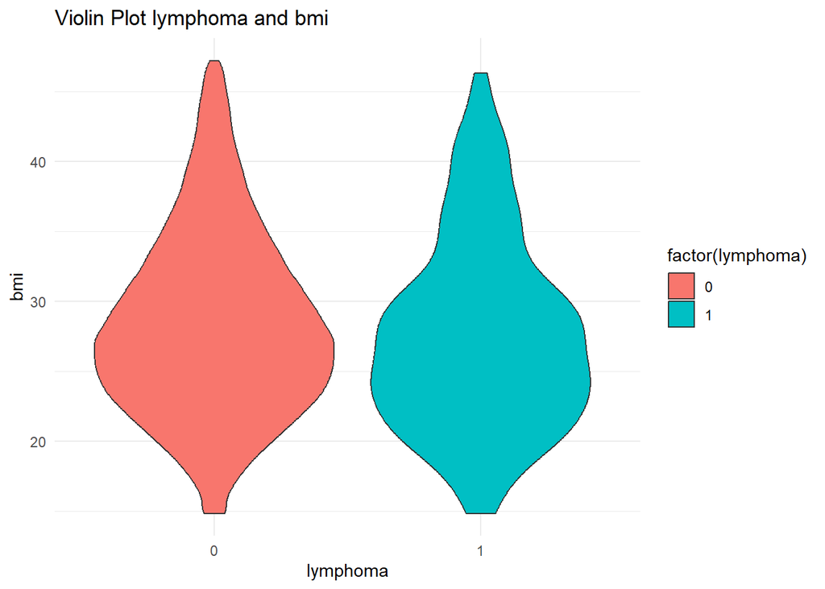

```r
# Violin Plot
ggplot(cleaned_data4, aes(x = factor(lymphoma), y = bmi, fill = factor(lymphoma))) +
  geom_violin() +
  labs(title = "Violin Plot lymphoma and bmi",
       x = "lymphoma", y = "bmi") +
  theme_minimal()
```

```r
#ggplot(cleaned_data4, aes(x=heart_rate_apache,y=bmi, color=age))+geom_point()+labs(title="heart rate vs bmi color coded based on #age")
```

Hypothesis testing

Contingency table and chi square test

Contingency tables have been used for this project to understand the relationship between two categorical variables (ie., strings, in our case “yes” or “no” data columns). Hospital death is the target column of our dataset. Hence, to assess the impact of various diseases such as diabetes, cirrhosis etc., on the hospital death, contingency table was drawn. This table shows the counts or frequencies of observations. A chi square test of this contingency table will reveal whether there is any dependence between the variables. Null Hypothesis H0: There is no dependence between variables. Alternate Hypothesis H1: There is dependence between variables. After doing the chi square tests, it was observed that, there is significant association/dependence between variables like cirrhosis, leukemia, lymphoma, and diabetes against hospital death. This can be inferred from the low p value ie., less than 0.05 (95 percent confidence interval). Here, we are rejecting the null hypothesis. A higher p value indicates independence whereas low p value indicates dependence. Hence, factors like cirrhosis and diabetes are responsible, or have an impact on whether a person lives or dies.

```r
contingency_table <- table(cleaned_data4$cirrhosis, cleaned_data4$hospital_death)
print(contingency_table)
```

```
##
##         0     1
##   0 70160  5923
##   1  1083   213
```

```r
chi_square_result <- chisq.test(table(cleaned_data4$hospital_death, cleaned_data4$cirrhosis))
print(chi_square_result)
```

```
##
##  Pearson's Chi-squared test with Yates' continuity correction
##
## data:  table(cleaned_data4$hospital_death, cleaned_data4$cirrhosis)
## X-squared = 129, df = 1, p-value <2e-16
```

```r
contingency_table1 <- table(cleaned_data4$leukemia, cleaned_data4$hospital_death)
print(contingency_table1)
```

```
##
##         0     1
##   0 70772  6036
##   1   471   100
```

```r
chi_square_result1 <- chisq.test(table(cleaned_data4$hospital_death, cleaned_data4$leukemia))
print(chi_square_result1)
```

```
##
##  Pearson's Chi-squared test with Yates' continuity correction
##
## data:  table(cleaned_data4$hospital_death, cleaned_data4$leukemia)
## X-squared = 71, df = 1, p-value <2e-16
```

```r
contingency_table2 <- table(cleaned_data4$lymphoma, cleaned_data4$hospital_death)
print(contingency_table2)
```

```
##
##         0     1
##   0 70958  6080
##   1   285    56
```

```r
chi_square_result2 <- chisq.test(table(cleaned_data4$hospital_death, cleaned_data4$lymphoma))
print(chi_square_result2)
```

```
##
##  Pearson's Chi-squared test with Yates' continuity correction
##
## data:  table(cleaned_data4$hospital_death, cleaned_data4$lymphoma)
## X-squared = 33, df = 1, p-value = 1e-08
```

```r
contingency_table3 <- table(cleaned_data4$diabetes_mellitus, cleaned_data4$hospital_death)
print(contingency_table3)
```

```
##
##         0     1
##   0 55049  4872
##   1 16194  1264
```

```r
chi_square_result3 <- chisq.test(table(cleaned_data4$hospital_death, cleaned_data4$diabetes_mellitus))
print(chi_square_result3)
```

```
##
##  Pearson's Chi-squared test with Yates' continuity correction
##
## data:  table(cleaned_data4$hospital_death, cleaned_data4$diabetes_mellitus)
## X-squared = 15, df = 1, p-value = 1e-04
```

```r
contingency_table4 <- table(cleaned_data4$hepatic_failure, cleaned_data4$hospital_death)
print(contingency_table4)
```

```
##
##         0     1
##   0 70355  5953
##   1   888   183
```

```r
chi_square_result4 <- chisq.test(table(cleaned_data4$hospital_death, cleaned_data4$hepatic_failure))
print(chi_square_result4)
```

```
##
##  Pearson's Chi-squared test with Yates' continuity correction
##
## data:  table(cleaned_data4$hospital_death, cleaned_data4$hepatic_failure)
## X-squared = 123, df = 1, p-value <2e-16
```

[figure not shown]

```r
barplot(contingency_table, beside = TRUE, legend = TRUE,
        col = c("lightblue", "lightgreen"),
        main = "Bar Chart for cirrhosis vs hospital death",
        names.arg = c("Binary1=0", "Binary1=1"),
        xlab = "Cirrhosis", ylab = "Hospital death")
```

Anova test (Analysis of Variance) & post hoc Tukey HSD test

Anova test is used to compare means of different groups. Here, the anova test has been done on heart rate based on different icu groups. We can find out whether the means of these groups have any difference or not. If they have difference we can infer that icu type has impact on heart rate and icu’s vary in functionality which may help in improving a patient’s health. Null Hypothesis H0: There is no difference between group means. Alternate Hypothesis H1: Atleast one group mean is different from others. The output of the Anova test is representing a low p value ie., < 0.05 (95 percent confidence interval), which indicates that atleast one group mean varies from the others. Hence, we are rejecting the null hypothesis. To confirm this and find out which group mean varies, post hoc test such as Tukey’s HSD (honestly significant difference) test has been done. Since, the p adjusted values of most of the group means is less than 0.05, it can be inferred that more than one group mean or means of multiple groups have significant difference.

```r
atest1<-aov(heart_rate_apache ~ icu_type,data=cleaned_data4)
print(summary(atest1))
```

```
##                Df   Sum Sq Mean Sq F value Pr(>F)
## icu_type        7   879993  125713     149 <2e-16 ***
## Residuals   77371 65098375     841
## ---
## Signif. codes:  0 '***' 0.001 '**' 0.01 '*' 0.05 '.' 0.1 ' ' 1
```

```r
library(TukeyC)
hoctest<-TukeyHSD(atest1)
hoctest
```

```
##   Tukey multiple comparisons of means
##     95% family-wise confidence level
##
## Fit: aov(formula = heart_rate_apache ~ icu_type, data = cleaned_data4)
##
## $icu_type
##                            diff    lwr     upr p adj
## CCU-CTICU-Cardiac ICU    -1.841 -3.624 -0.0570 0.037
## CSICU-Cardiac ICU        -6.133 -8.068 -4.1977 0.000
## CTICU-Cardiac ICU        -3.748 -5.785 -1.7109 0.000
## Med-Surg ICU-Cardiac ICU  3.990  2.546  5.4340 0.000
## MICU-Cardiac ICU          6.147  4.391  7.9032 0.000
## Neuro ICU-Cardiac ICU    -1.713 -3.464  0.0381 0.060
## SICU-Cardiac ICU          3.793  1.885  5.7019 0.000
## CSICU-CCU-CTICU          -4.292 -6.059 -2.5254 0.000
## CTICU-CCU-CTICU          -1.908 -3.786 -0.0294 0.043
## Med-Surg ICU-CCU-CTICU    5.830  4.621  7.0399 0.000
## MICU-CCU-CTICU            7.988  6.419  9.5565 0.000
## Neuro ICU-CCU-CTICU       0.127 -1.436  1.6908 1.000
## SICU-CCU-CTICU            5.634  3.896  7.3717 0.000
## CTICU-CSICU               2.385  0.362  4.4072 0.008
## Med-Surg ICU-CSICU       10.123  8.699 11.5460 0.000
## MICU-CSICU               12.280 10.541 14.0190 0.000
## Neuro ICU-CSICU           4.420  2.685  6.1538 0.000
## SICU-CSICU                9.926  8.033 11.8190 0.000
## Med-Surg ICU-CTICU        7.738  6.178  9.2974 0.000
## MICU-CTICU                9.895  8.043 11.7473 0.000
## Neuro ICU-CTICU           2.035  0.187  3.8824 0.019
## SICU-CTICU                7.541  5.544  9.5386 0.000
## MICU-Med-Surg ICU         2.157  0.988  3.3261 0.000
## Neuro ICU-Med-Surg ICU   -5.703 -6.864 -4.5416 0.000
## SICU-Med-Surg ICU        -0.197 -1.584  1.1909 1.000
## Neuro ICU-MICU           -7.860 -9.392 -6.3281 0.000
## SICU-MICU                -2.354 -4.064 -0.6440 0.001
## SICU-Neuro ICU            5.506  3.802  7.2112 0.000
```

Encoding categorical variables

```r
library(caret)
encoding <- dummyVars("~ .", data = cleaned_data4)
encoded_data <- predict(encoding, newdata = cleaned_data4)
#print(encoded_data)
summary(encoded_data)
```

```
##    patient_id      hospital_id  hospital_death       age            bmi
##  Min.   :     1   Min.   :  2   Min.   :0.000   Min.   :20.0   Min.   :14.8
##  1st Qu.: 32860   1st Qu.: 47   1st Qu.:0.000   1st Qu.:53.0   1st Qu.:23.7
##  Median : 65377   Median :112   Median :0.000   Median :65.0   Median :27.5
##  Mean   : 65541   Mean   :106   Mean   :0.079   Mean   :62.9   Mean   :28.4
##  3rd Qu.: 98323   3rd Qu.:166   3rd Qu.:0.000   3rd Qu.:76.0   3rd Qu.:32.4
##  Max.   :131051   Max.   :204   Max.   :1.000   Max.   :89.0   Max.   :47.2
##    ethnicity. ethnicity.African American ethnicity.Asian ethnicity.Caucasian
##  Min.   :0    Min.   :0.000              Min.   :0.000   Min.   :0.00
##  1st Qu.:0    1st Qu.:0.000              1st Qu.:0.000   1st Qu.:1.00
##  Median :0    Median :0.000              Median :0.000   Median :1.00
##  Mean   :0    Mean   :0.106              Mean   :0.013   Mean   :0.78
##  3rd Qu.:0    3rd Qu.:0.000              3rd Qu.:0.000   3rd Qu.:1.00
##  Max.   :0    Max.   :1.000              Max.   :1.000   Max.   :1.00
##  ethnicity.Hispanic ethnicity.Native American ethnicity.Other/Unknown
##  Min.   :0.000      Min.   :0.000             Min.   :0.00
##  1st Qu.:0.000      1st Qu.:0.000             1st Qu.:0.00
##  Median :0.000      Median :0.000             Median :0.00
##  Mean   :0.041      Mean   :0.009             Mean   :0.05
##  3rd Qu.:0.000      3rd Qu.:0.000             3rd Qu.:0.00
##  Max.   :1.000      Max.   :1.000             Max.   :1.00
##  gender.Cardiac ICU gender.CCU-CTICU  gender.CSICU    gender.CTICU
##  Min.   :0.000      Min.   :0.000    Min.   :0.000   Min.   :0.000
##  1st Qu.:0.000      1st Qu.:0.000    1st Qu.:0.000   1st Qu.:0.000
##  Median :0.000      Median :0.000    Median :0.000   Median :0.000
##  Mean   :0.053      Mean   :0.078    Mean   :0.054   Mean   :0.044
##  3rd Qu.:0.000      3rd Qu.:0.000    3rd Qu.:0.000   3rd Qu.:0.000
##  Max.   :1.000      Max.   :1.000    Max.   :1.000   Max.   :1.000
##  gender.Med-Surg ICU  gender.MICU    gender.Neuro ICU  gender.SICU
##  Min.   :0.000       Min.   :0.000   Min.   :0.000    Min.   :0.000
##  1st Qu.:0.000       1st Qu.:0.000   1st Qu.:0.000    1st Qu.:0.000
##  Median :1.000       Median :0.000   Median :0.000    Median :0.000
##  Mean   :0.543       Mean   :0.084   Mean   :0.086    Mean   :0.057
##  3rd Qu.:1.000       3rd Qu.:0.000   3rd Qu.:0.000    3rd Qu.:0.000
##  Max.   :1.000       Max.   :1.000   Max.   :1.000    Max.   :1.000
##  icu_typeCardiac ICU icu_typeCCU-CTICU icu_typeCSICU   icu_typeCTICU
##  Min.   :0.000       Min.   :0.000     Min.   :0.000   Min.   :0.000
##  1st Qu.:0.000       1st Qu.:0.000     1st Qu.:0.000   1st Qu.:0.000
##  Median :0.000       Median :0.000     Median :0.000   Median :0.000
##  Mean   :0.053       Mean   :0.078     Mean   :0.054   Mean   :0.044
```

[output cut: 8 more lines]

```
##  Max.   :1.000        Max.   :1.000   Max.   :1.000     Max.   :1.000
##  heart_rate_apache diabetes_mellitus   cirrhosis     hepatic_failure
##  Min.   : 38       Min.   :0.000     Min.   :0.000   Min.   :0.000
##  1st Qu.: 88       1st Qu.:0.000     1st Qu.:0.000   1st Qu.:0.000
##  Median :104       Median :0.000     Median :0.000   Median :0.000
##  Mean   :100       Mean   :0.226     Mean   :0.017   Mean   :0.014
##  3rd Qu.:120       3rd Qu.:0.000     3rd Qu.:0.000   3rd Qu.:0.000
##  Max.   :169       Max.   :1.000     Max.   :1.000   Max.   :1.000
##     leukemia        lymphoma
##  Min.   :0.000   Min.   :0.000
##  1st Qu.:0.000   1st Qu.:0.000
##  Median :0.000   Median :0.000
##  Mean   :0.007   Mean   :0.004
##  3rd Qu.:0.000   3rd Qu.:0.000
##  Max.   :1.000   Max.   :1.000
```

```r
str(encoded_data)
```

```
##  num [1:77379, 1:34] 25312 59342 50777 46918 74489 ...
##  - attr(*, "dimnames")=List of 2
##   ..$ : chr [1:77379] "1" "2" "3" "4" ...
##   ..$ : chr [1:34] "patient_id" "hospital_id" "hospital_death" "age" ...
```

```r
m=as.data.frame(encoded_data)
#print(m)
str(m)
```

```
## 'data.frame':    77379 obs. of  34 variables:
##  $ patient_id                : num  25312 59342 50777 46918 74489 ...
##  $ hospital_id               : num  118 81 118 118 83 77 83 118 81 118 ...
##  $ hospital_death            : num  0 0 0 0 0 0 0 0 0 0 ...
##  $ age                       : num  68 77 25 81 67 72 80 81 30 46 ...
##  $ bmi                       : num  22.7 27.4 31.9 22.6 27.6 ...
##  $ ethnicity.                : num  0 0 0 0 0 0 0 0 0 0 ...
##  $ ethnicity.African American: num  0 0 0 0 0 0 0 0 0 0 ...
##  $ ethnicity.Asian           : num  0 0 0 0 0 0 0 0 0 0 ...
##  $ ethnicity.Caucasian       : num  1 1 1 1 1 0 1 1 1 0 ...
##  $ ethnicity.Hispanic        : num  0 0 0 0 0 1 0 0 0 1 ...
##  $ ethnicity.Native American : num  0 0 0 0 0 0 0 0 0 0 ...
##  $ ethnicity.Other/Unknown   : num  0 0 0 0 0 0 0 0 0 0 ...
##  $ gender.Cardiac ICU        : num  0 0 0 0 0 0 0 0 0 0 ...
##  $ gender.CCU-CTICU          : num  0 0 0 0 0 0 0 0 0 0 ...
```

[output cut: 20 more lines]

An attempt at reducing skewness in bmi column

Log transformation

```r
#install.packages("e1071")
library(e1071)

skew_before <- skewness(m$bmi)
print(skew_before)
```

```
## [1] 0.508
```

```r
#Log transformation
transformed_data <- log(m$bmi + 1)
print(skewness(transformed_data))
```

```
## [1] -0.0368
```

```r
m$bmi<-transformed_data
```